# Breast Cancer Data Analysis

Download miRNA Primary tumor and Solid Tissue Normal Data

```r
query_miRNA_tumor <- GDCquery(
  project = cancer_type,
  data.category = "Transcriptome Profiling",
  data.type = "miRNA Expression Quantification",
  workflow.type = "BCGSC miRNA Profiling",
  sample.type = c("Primary Tumor")
)

GDCdownload(query_miRNA_tumor)
miRNA_tumor <- GDCprepare(
  query = query_miRNA_tumor
)

query_miRNA_normal <- GDCquery(
  project = cancer_type,
  data.category = "Transcriptome Profiling",
  data.type = "miRNA Expression Quantification",
  workflow.type = "BCGSC miRNA Profiling",
  sample.type = c("Solid Tissue Normal")
)

GDCdownload(query_miRNA_normal)
miRNA_normal <- GDCprepare(
  query = query_miRNA_normal
)
```

Here to maintain consistency, we want to make sure that samples used in miRNA differential expression analysis are the same as the samples used in gene differential expression analysis.

```r
contains_cross_mapped <- function(column_name) {
  return(grepl("cross-mapped", column_name))
}

contains_reads_per_million <- function(column_name) {
  return(grepl("reads_per_million", column_name))
}

extract_base_sample_id <- function(id) {
  return(substr(id, 1, nchar(id) -9))
}

extract_base_id_mirna <- function(full_id) {
  # Assuming the format is always "read_count_" followed by the TCGA ID
  id_parts <- strsplit(full_id, "_")[[1]]
  base_id <- id_parts[length(id_parts)] # Get the last part after splitting
  base_id <- unlist(strsplit(base_id, "-"))[1:3]
  return(paste(base_id, collapse = "-"))
}

rownames(miRNA_tumor) <- miRNA_tumor$miRNA_ID
rownames(miRNA_normal) <- miRNA_normal$miRNA_ID

# Apply to miRNA data
mirna_base_ids_tumor <- sapply(colnames(miRNA_tumor), extract_base_id_mirna)
mirna_base_ids_normal <- sapply(colnames(miRNA_normal), extract_base_id_mirna)

miRNA_filtered_tumor <- miRNA_tumor[, !sapply(colnames(miRNA_tumor), contains_cross_mapped)]
miRNA_filtered_normal <- miRNA_normal[, !sapply(colnames(miRNA_normal), contains_cross_mapped)]
miRNA_filtered_tumor <- miRNA_filtered_tumor[, !sapply(colnames(miRNA_filtered_tumor), contains_reads_per_million)]
miRNA_filtered_normal <- miRNA_filtered_normal[, !sapply(colnames(miRNA_filtered_normal), contains_reads_per_million)]

# Function to remove "read_count_" prefix from the IDs
remove_read_count_prefix <- function(id) {
  gsub("read_count_", "", id)
}

colnames(miRNA_filtered_tumor) <- sapply(colnames(miRNA_filtered_tumor), remove_read_count_prefix)
colnames(miRNA_filtered_normal) <- sapply(colnames(miRNA_filtered_normal), remove_read_count_prefix)

# Remove the 'miRNA_ID' column from both
miRNA_filtered_normal <- miRNA_filtered_normal[, !names(miRNA_filtered_normal) %in% "miRNA_ID"]
miRNA_filtered_tumor <- miRNA_filtered_tumor[, !names(miRNA_filtered_tumor) %in% "miRNA_ID"]

# Apply the function to the column names of both data frames
exp_filtered_tumor_base_ids <- sapply(colnames(exp_filtered_tumor), extract_base_sample_id)
miRNA_filtered_tumor_base_ids <- sapply(colnames(miRNA_filtered_tumor), extract_base_sample_id)

# Find common base sample IDs
common_base_samples <- dplyr::intersect(exp_filtered_tumor_base_ids, miRNA_filtered_tumor_base_ids)

# Filter both data frames to only include columns with common base sample IDs
exp_filtered_tumor_common <- exp_filtered_tumor[, exp_filtered_tumor_base_ids %in% common_base_samples]
miRNA_filtered_tumor_common <- miRNA_filtered_tumor[, miRNA_filtered_tumor_base_ids %in% common_base_samples]

# Ensure the columns are in the same order for both data frames
exp_filtered_tumor_common <- exp_filtered_tumor_common[, order(colnames(exp_filtered_tumor_common))]
miRNA_filtered_tumor_common <- miRNA_filtered_tumor_common[, order(colnames(miRNA_filtered_tumor_common))]

# Count frequency of each common base sample ID in miRNA_filtered_tumor_base_ids
miRNA_count <- table(miRNA_filtered_tumor_base_ids[miRNA_filtered_tumor_base_ids %in% common_base_samples])
# Count frequency of each common base sample ID in exp_filtered_tumor_base_ids
exp_count <- table(exp_filtered_tumor_base_ids[exp_filtered_tumor_base_ids %in% common_base_samples])
# Combine the counts into a data frame for easy viewing
combined_counts <- data.frame(
  SampleID = names(miRNA_count),
  miRNA_Count = as.integer(miRNA_count),
  exp_Count = as.integer(exp_count[names(miRNA_count)])
)

duplicates <- combined_counts$SampleID[combined_counts$miRNA_Count > 1 | combined_counts$exp_Count > 1]
exp_filtered_tumor_common <- exp_filtered_tumor_common[, !colnames(exp_filtered_tumor_common) %in% duplicates]
miRNA_filtered_tumor_common <- miRNA_filtered_tumor_common[, !colnames(miRNA_filtered_tumor_common) %in% duplicates]

# Function to check if any of the duplicates are in a given column name
has_duplicate <- function(column_name, duplicates) {
  any(sapply(duplicates, function(duplicate) grepl(duplicate, column_name)))
}

# Apply the function to each column name and negate the result to filter out duplicates
exp_filtered_tumor_common <- exp_filtered_tumor_common[, !sapply(colnames(exp_filtered_tumor_common), has_duplicate, duplicates=duplicates)]
miRNA_filtered_tumor_common <- miRNA_filtered_tumor_common[, !sapply(colnames(miRNA_filtered_tumor_common), has_duplicate, duplicates=duplicates)]

dim(exp_filtered_tumor_common)
```

```
## [1] 54314   202
```

```r
dim(miRNA_filtered_tumor_common)
```

```
## [1] 1881  202
```

Save filtered miRNA data

```r
file_miRNA_tumor <- paste(paste("miRNA_filtered_tumor_common", subtype, sep="_"), "rds", sep=".")
saveRDS(miRNA_filtered_tumor_common, file = file_miRNA_tumor)
file_miRNA_normal <- paste(paste("miRNA_filtered_normal", subtype, sep="_"), "rds", sep=".")
saveRDS(miRNA_filtered_normal, file = file_miRNA_normal)
```

Run miRNA differential expression analysis

```r
diff_expressed_miRNA <- TCGAanalyze_DEA(
  mat1 = miRNA_filtered_normal,
  mat2 = miRNA_filtered_tumor_common,
  Cond1type = "Normal",
  Cond2type = "Tumor",
  fdr.cut = 0.05 ,
  logFC.cut = 0,
  method = "glmLRT"
)
```

```
## Batch correction skipped since no factors provided
```

```
## ----------------------- DEA -------------------------------
```

```
## o 104 samples in Cond1type Normal
```

```
## o 202 samples in Cond2type Tumor
```

```
## o 1881 features as miRNA or genes
```

```
## This may take some minutes...
```

```
## ----------------------- END DEA -------------------------------
```

```r
# Sort the diff_expressed_miRNA data frame by logFC in descending order to get the genes with the highest fold changes first
sorted_diff_expressed_miRNA <- diff_expressed_miRNA %>% arrange(desc(logFC))

file_path_mirna <- paste(paste("diff_expressed_miRNA", subtype, sep="_"), "xlsx", sep=".")

write.xlsx(sorted_diff_expressed_miRNA, file = file_path_mirna, rowNames = TRUE)
```

Lets look at the top upregulated miRNAs

```r
head(sorted_diff_expressed_miRNA, 10)
```

```
##                   logFC   logCPM        LR       PValue          FDR
## hsa-mir-1269a  6.804819 6.463610 119.47987 8.222560e-28 1.128951e-26
## hsa-mir-449a   6.561816 4.007116 129.36893 5.631495e-30 8.612067e-29
## hsa-mir-1269b  6.116191 3.126153  52.92787 3.460248e-13 2.229016e-12
## hsa-mir-767    5.942019 3.111122  59.43837 1.261849e-14 9.128994e-14
## hsa-mir-105-1  5.917838 3.612357  73.49178 1.010561e-17 8.882544e-17
## hsa-mir-105-2  5.895766 3.627488  63.90027 1.308800e-15 1.008956e-14
## hsa-mir-449c   5.424732 1.033670  83.73316 5.662748e-20 5.518979e-19
## hsa-mir-449b   5.402629 1.897858  95.95899 1.172882e-22 1.313209e-21
## hsa-mir-3156-1 5.275305 1.058410  59.62876 1.145488e-14 8.416655e-14
## hsa-mir-4724   5.159294 1.781761 244.03190 5.195191e-55 2.079182e-53
```

Lets look at the top downregulated miRNAs

```r
sorted_diff_expressed_miRNA_asc <- diff_expressed_miRNA %>% arrange(logFC)
head(sorted_diff_expressed_miRNA_asc, 10)
```

```
##                    logFC      logCPM        LR       PValue          FDR
## hsa-mir-206    -6.852999  6.69400425  81.55242 1.706745e-19 1.629638e-18
## hsa-mir-133b   -6.550500  4.70020041 136.53364 1.525079e-31 2.607885e-30
## hsa-mir-1-1    -6.477141  6.29018007 379.21160 1.847601e-84 1.654923e-82
## hsa-mir-1-2    -6.446111  6.38475098 406.09105 2.600249e-90 2.877099e-88
## hsa-mir-133a-1 -6.235924  6.05547302 319.80639 1.596152e-71 1.072272e-69
## hsa-mir-133a-2 -6.132129  5.85894346 322.40765 4.329808e-72 3.016433e-70
## hsa-mir-486-2  -4.685842  8.26925589 431.42190 7.969166e-96 9.993334e-94
## hsa-mir-486-1  -4.675660  8.27909879 430.53397 1.243566e-95 1.461967e-93
## hsa-mir-208b   -3.990890 -0.05201834  23.22497 1.441138e-06 6.050851e-06
## hsa-mir-451a   -3.600558 10.04907461 312.07307 7.720127e-70 4.537987e-68
```

## Find highly negatively correlated Gene-miRNA pairs

```r
library(dplyr)
library(openxlsx)


findCorrelatedPairs <- function(genes_df, miRNAs_df, gene_logFC_threshold, miRNA_logFC_threshold, cutoff=-0.4) {
  filtered_genes <- genes_df
  filtered_miRNAs <- miRNAs_df
  correlated_pairs <- list()
  #total_operations <- length(rownames(filtered_genes)) * length(rownames(filtered_miRNAs))
  #progress_bar <- txtProgressBar(min = 0, max = total_operations, style = 3)
  operation_count <- 0
  for (gene in rownames(filtered_genes)) {
    for (mirna in rownames(filtered_miRNAs)) {
      #operation_count <- operation_count + 1
      #setTxtProgressBar(progress_bar, operation_count)
      gene_name <- filtered_genes[gene, "gene_name"]
      # Run Spearman correlation
      correlation <- suppressWarnings(cor.test(as.numeric(exp_filtered_tumor_common[gene,]), as.numeric(miRNA_filtered_tumor_common[mirna,]), method = "spearman"))
      # Check for the correlation threshold
      if (!is.na(correlation$estimate) && correlation$estimate <= cutoff) {
        correlated_pairs[[paste(gene_name, mirna, sep = "_")]] <- c(correlation$estimate, correlation$p.value)
      }
    }
  }

  #close(progress_bar)

  # Convert the list to a dataframe
  correlated_pairs_df <- do.call(rbind, lapply(names(correlated_pairs), function(x) {
    parts <- unlist(strsplit(x, "_"))
    data.frame(
      gene = parts[1],
      miRNA = parts[2],
      correlation = correlated_pairs[[x]][1],
      p_value = correlated_pairs[[x]][2]
    )
  }))

  # Return the dataframe
  return(correlated_pairs_df)
}

# For upregulated genes and downregulated miRNAs
upregulated_genes <- diff_expressed_genes %>% dplyr::filter(logFC > 2)
downregulated_miRNA <- diff_expressed_miRNA %>% dplyr::filter(logFC < -2)
correlated_pairs_up_down <- findCorrelatedPairs(upregulated_genes, downregulated_miRNA)
file_path <- paste(paste("correlated_pairs_upgene_downmirna", subtype, sep="_"), "xlsx", sep=".")
write.xlsx(correlated_pairs_up_down, file = file_path, rowNames = FALSE)

# For downregulated genes and upregulated miRNAs
downregulated_genes <- diff_expressed_genes %>% dplyr::filter(logFC < -2)
upregulated_miRNA <- diff_expressed_miRNA %>% dplyr::filter(logFC > 2)
correlated_pairs_down_up <- findCorrelatedPairs(downregulated_genes, upregulated_miRNA)
file_path <- paste(paste("correlated_pairs_downgene_upmirna", subtype, sep="_"), "xlsx", sep=".")
write.xlsx(correlated_pairs_down_up, file = file_path, rowNames = FALSE)
```

Results: Upregulated genes-Downregulated miRNA

```r
head(correlated_pairs_up_down, 10)
```

[output not shown]

Results: Downregulated genes-Upregulated miRNA

```r
head(correlated_pairs_down_up, 10)
```

```
##         gene        miRNA correlation      p_value
## rho MIR205HG hsa-mir-4714   -0.427196 2.291226e-10
```

There are no hits within our correlation and gene expression cutoff range in upregulated gene and downregulated miRNA correlation result, whereas there is just one hit in downregulated gene+lncRNA and upregulated miRNA correlation result. It is interesting to note that lncRNA MIR205HG shows a fairly high negative correlation with miRNA hsa-mir-4714, indicating its regulatory impact on hsa-mir-4714. Given that there are no negative correlation between hsa-mir-4714 and protein coding, importance of MIR205HG negative correlation with hsa-mir-4714 needs further investigation. Lets quickly change the correlation cutoff to -0.3 to check if hsa-mir-4714 negatively correlates with any protein coding genes.

```r
correlated_pairs_down_up_c03 <- findCorrelatedPairs(downregulated_genes, upregulated_miRNA, cutoff=-0.3)
file_path <- paste(paste("correlated_pairs_downgene_upmirna_cutoff_0.3", subtype, sep="_"), "xlsx", sep=".")
write.xlsx(correlated_pairs_down_up_c03, file = file_path, rowNames = FALSE)
filtered_rows <- correlated_pairs_down_up %>% dplyr::filter(miRNA == 'hsa-mir-4714') #check if there are any protein coding gene hits with hsa-mir-1247
head(filtered_rows, 10)
```

```
##         gene        miRNA correlation      p_value
## rho MIR205HG hsa-mir-4714   -0.427196 2.291226e-10
```

```r
gc()
rm(miRNA_normal)
rm(miRNA_tumor)
rm(miRNA_filtered_normal)
rm(miRNA_filtered_tumor)
rm(miRNA_filtered_tumor_common)
rm(mirna_base_ids_normal)
rm(mirna_base_ids_tumor)
rm(miRNA_count)
rm(miRNA_filtered_tumor_base_ids)
rm(clinical_data)
rm(combined_counts)
rm(exp_tumor_subtype)
```

## Methylation data analysis

Download Methylation data

```r
group.col <- "sample_type"
group1 <- "Primary Tumor"
group2 <- "Solid Tissue Normal"

query_met_tumor <- GDCquery(
  project = cancer_type,
  data.category = "DNA Methylation",
  platform = "Illumina Human Methylation 450",
  data.type = "Methylation Beta Value",
  sample.type = c("Primary Tumor")
)

GDCdownload(query_met_tumor)
met_tumor <- GDCprepare(query_met_tumor, save = FALSE)

query_met_normal <- GDCquery(
  project = cancer_type,
  data.category = "DNA Methylation",
  platform = "Illumina Human Methylation 450",
  data.type = "Methylation Beta Value",
  sample.type = c("Solid Tissue Normal")
)

GDCdownload(query_met_normal)
met_normal <- GDCprepare(query_met_normal, save = FALSE)
```

Pull subtype methylation data and merge it with normal sample methylotion data

```r
clinical_data <- GDCquery_clinic(project = "TCGA-BRCA", type = "clinical")
metadata <- colData(met_tumor) # contains dataframe with PAM50 tumor classifications and other clinical data for each sample
LumB_samples <- metadata[!is.na(metadata$paper_BRCA_Subtype_PAM50) & metadata$paper_BRCA_Subtype_PAM50 == subtype,]
# It is important to note that sample ids in exp_tumor is large ids with extra characters and samples$bcr_patient_barcode
# has trunctued id format. Therefore to match these and pull subtype sample expression data, we need following

matched_columns <- sapply(colnames(met_tumor), function(column_name) {
  any(sapply(subtype_samples$bcr_patient_barcode, function(truncated_id) {
    grepl(truncated_id, column_name)
  }))
})

met_tumor_filtered <- met_tumor[, matched_columns]
common_met <- dplyr::intersect(rownames(met_tumor_filtered), rownames(met_normal))
# Subset each dataset to include only common genes
met_filtered_tumor_common <- met_tumor_filtered[common_met, ]
met_filtered_normal_common <- met_normal[common_met, ]

# Subset tumor dataset for common CpG islands
met_filtered_tumor_common <- met_filtered_tumor_common[rownames(met_filtered_tumor_common) %in% rownames(met_filtered_normal_common), ]
# Subset normal dataset for common CpG islands
met_filtered_normal_common <- met_filtered_normal_common[rownames(met_filtered_normal_common) %in% rownames(met_filtered_tumor_common), ]

# Merge Tumor and Normal methylation data
assay_tumor <- assay(met_filtered_tumor_common)
assay_normal <- assay(met_filtered_normal_common)
met <- cbind(assay_tumor, assay_normal)
rm(clinical_data)
```

Combine methylation and gene expression data

```r
library(ELMER)


distal.probes <- get.feature.probe(
  genome = "hg19",
  met.platform = "450K"
)

mae <- createMAE(
  exp = assay(exp_combined),
  met = met,
  save = TRUE,
  linearize.exp = TRUE,
  save.filename = "mae.rda",
  filter.probes = distal.probes,
  met.platform = "450K",
  genome = "hg19",
  TCGA = TRUE
)

fname = paste(paste("mae", subtype, sep="_"), "rds", sep=".")
saveRDS(mae, file = fname)

mae <- readRDS(fname)

rm(exp_filtered_tumor_common)
rm(exp_filtered_normal_common)
rm(met)
rm(met_tumor)
rm(met_normal)
rm(assay_normal)
rm(assay_tumor)
rm(exp_combined)
rm(met_normal_filtered)
rm(met_filtered_normal_common)
rm(met_filtered_tumor_common)
gc()
```

Methylation data analysis function

```r
library(ELMER)
library(openxlsx)
library(dplyr)

runMethylationTest <- function(direction, subtype, mae) {
  message("Get diff methylated probes")
  cores <- 8
  group.col <- "sample_type"
  group1 <- "Primary Tumor"
  group2 <- "Solid Tissue Normal"

  dir.out <- paste0("elmer/",direction)
  dir.create(dir.out, showWarnings = FALSE, recursive = TRUE)
  Sig.probes <- get.diff.meth(
    data = mae,
    group.col = group.col,
    group1 = group1,
    group2 =  group2,
    minSubgroupFrac = 1.0,
    sig.dif = 0.2,
    diff.dir = direction,
    cores = cores,
    dir.out = dir.out,
    pvalue = 0.05
  )

  message("Get nearby genes")
  nearGenes <- GetNearGenes(
    data = mae,
    numFlankingGenes = 4, # default is 20 genes
    probes = Sig.probes$probe
  )

  rm(Sig.probes)

  message("Get anti correlated probes-genes")
  sig_pair <- get.pair(
    data = mae,
    group.col = group.col,
    group1 = group1,
    group2 =  group2,
    nearGenes = nearGenes,
    mode = "supervised",
    minSubgroupFrac = 1,
    raw.pvalue = 0.05,
    Pe = 0.05,
    filter.probes = TRUE,
    filter.percentage = 0.05,
    save = FALSE,
    filter.portion = 0.2,
    dir.out = dir.out,
    diff.dir = direction,
    cores = cores,
    label = direction
  )

  fname = paste(paste(paste("pair", direction, sep="_"), subtype, sep="_"), "xlsx", sep=".")
  write.xlsx(sig_pair, file = fname)

  gc()

  enriched.motif <- get.enriched.motif(
    data = mae,
    probes = sig_pair$Probe,
    dir.out = dir.out,
    label = direction,
    pvalue = 0.05, # default is FDR < 0.05
    min.incidence = 10,
    lower.OR = 1.1
  )

  # Write TF binding to gene differentially methylated sites
  motif_data <- stack(enriched.motif)
  colnames(motif_data) <- c("Probe", "Motif")
  combined_data <- sig_pair %>%
    dplyr::select(Probe, Symbol) %>%
    inner_join(motif_data, by = "Probe")

  result <- combined_data %>%
    group_by(Symbol) %>%
    summarize(Motifs = paste(unique(Motif), collapse = ", "))

  fname = paste(paste(paste("gene_Motif", direction, sep="_"), subtype, sep="_"), "csv", sep=".")
  write.csv(result, fname, row.names = TRUE)

  rm(motif_data)
  rm(sig_pair)
  rm(enriched.motif)

}
```

Run data analysis for Hypomethylation test

```r
gc()
output <- runMethylationTest(direction="hypo", subtype=subtype, mae=mae)
```

Lets look at the transcription factors binding to the Hypomethylated motifs of differentially expressed genes

```r
direction="hypo"
fname <- paste(paste(paste("gene_Motif", direction, sep="_"), subtype, sep="_"), "csv", sep=".")
result <- read.csv(fname, row.names = "Symbol")
result$X = NULL
head(result, 10)
```

```
##                                                                                                                                                                                                                                                                                                          …
## AATK                                                                                                                                                                                                                                                                                                     …
## ABCC1                                                                                                                                                                                                                                                                                                    …
## ABCD3                                                                                                                                                                                                                                                                                                    …
## ABHD17C                                                                                                                                                                                                                                                                                                  …
## AC000367.1                                                                                                                                                                                                                                                                                               …
## AC002044.4 FOXA3_HUMAN.H11MO.0.B, FOXA1_HUMAN.H11MO.0.A, FOXF2_HUMAN.H11MO.0.D, FOXC1_HUMAN.H11MO.0.C, FOXJ2_HUMAN.H11MO.0.C, FOXD1_HUMAN.H11MO.0.D, FOXO6_HUMAN.H11MO.0.D, FOXF1_HUMAN.H11MO.0.D, FOXO3_HUMAN.H11MO.0.B, FOXK1_HUMAN.H11MO.0.A, FOXP1_HUMAN.H11MO.0.A, CUX2_HUMAN.H11MO.0.D, FOXO4_HUMAN…
## AC002331.1                                                                                                                                                                             FOXB1_HUMAN.H11MO.0.D, FOXJ2_HUMAN.H11MO.0.C, GATA1_HUMAN.H11MO.1.A, GATA6_HUMAN.H11MO.0.A, GATA3_HUMAN.H11MO.0.A,…
## AC002365.1                                                                                                                                                                                                                                                                                               …
## AC002551.1                                                                                                                                                                                                                                                                                               …
## AC003989.3                                                                                                                                                                                                                                                                                               …
```

Run data analysis for Hypermethylation test

```r
gc()
output <- runMethylationTest(direction="hyper", subtype=subtype, mae=mae)
```

Lets look at the transcription factors binding to the Hypermethylated motifs of differentially expressed genes

```r
direction="hyper"
fname <- paste(paste(paste("gene_Motif", direction, sep="_"), subtype, sep="_"), "csv", sep=".")
result <- read.csv(fname, row.names = "Symbol")
result$X = NULL
head(result, 10)
```

```
##                                                                                                                                                                                                                                                                                                          …
## AACS                                                                                                                                                                                                                                                                                                     …
## AAED1                                                                                                                                                                                                                                                                                                    …
## AASS                                                                                                                                                                                                                                                                                                     …
## ABCB5                                                                                                     ZBT14_HUMAN.H11MO.0.C, SP2_HUMAN.H11MO.0.A, SP1_HUMAN.H11MO.0.A, SP3_HUMAN.H11MO.0.B, E2F4_HUMAN.H11MO.0.A, SP1_HUMAN.H11MO.1.A, THAP1_HUMAN.H11MO.0.C, KLF3_HUMAN.H11MO.0.B, MBD2_HUMAN.H11MO.…
## ABCD4                                                                                                                                                                                                                                                                                                    …
## ABL1       ZBT14_HUMAN.H11MO.0.C, SP2_HUMAN.H11MO.0.A, SP1_HUMAN.H11MO.0.A, SP3_HUMAN.H11MO.0.B, E2F4_HUMAN.H11MO.0.A, SP1_HUMAN.H11MO.1.A, THAP1_HUMAN.H11MO.0.C, KLF3_HUMAN.H11MO.0.B, MBD2_HUMAN.H11MO.0.B, E2F4_HUMAN.H11MO.1.A, AP2D_HUMAN.H11MO.0.D, MECP2_HUMAN.H11MO.0.C, E2F2_HUMAN.H11MO.0.B, W…
## ABLIM1                                                                                                                                                                                                                                                                                                   …
## ABTB1                                                                                                                                                                                                                                                                                                    …
## AC000036.4                                                                                                                                                                                                                                                                                               …
## AC002064.5                                                                                                                                                                                                                                                                                               …
```

## PATHWAY ANALYSIS

I am particularly interested in Leukocyte transendothelial migration pathway, since they are the gatekeeper of immune infiltration in cancer. Lets plot gene differential expression results on LTM pathway to visualize its changes.

```r
library(clusterProfiler)
library(SummarizedExperiment)
library(pathview)



# DEGs TopTable
dataDEGsFiltLevel <- TCGAanalyze_LevelTab(
  FC_FDR_table_mRNA = diff_expressed_genes,
  typeCond1 = "Tumor",
  typeCond2 = "Normal",
  TableCond1 = exp_filtered_tumor,
  TableCond2 = exp_filtered_normal
)

dataDEGsFiltLevel$GeneID <- 0

# Converting Gene symbol to geneID
eg = as.data.frame(
  bitr(
    dataDEGsFiltLevel$mRNA,
    fromType = "ENSEMBL",
    toType = c("ENTREZID","SYMBOL"),
    OrgDb = "org.Hs.eg.db"
  )
)
eg <- eg[!duplicated(eg$SYMBOL),]
eg <- eg[order(eg$SYMBOL,decreasing=FALSE),]

dataDEGsFiltLevel <- dataDEGsFiltLevel[dataDEGsFiltLevel$mRNA %in% eg$ENSEMBL,]
dataDEGsFiltLevel <- dataDEGsFiltLevel[eg$ENSEMBL,]
rownames(dataDEGsFiltLevel) <- eg$SYMBOL

all(eg$SYMBOL == rownames(dataDEGsFiltLevel))

dataDEGsFiltLevel$GeneID <- eg$ENTREZID

dataDEGsFiltLevel_sub <- subset(dataDEGsFiltLevel, select = c("GeneID", "logFC"))
genelistDEGs <- as.numeric(dataDEGsFiltLevel_sub$logFC)
names(genelistDEGs) <- dataDEGsFiltLevel_sub$GeneID

hsa04670 <- pathview::pathview(
  gene.data  = genelistDEGs,
  pathway.id = "hsa04670",
  species    = "hsa"
)
```

[figure not shown]

```r
knitr::include_graphics("hsa04670.pathview.png")
```

Changes in methylation patterns can significantly impact gene expression by altering the accessibility of transcription factors to their binding motifs on the DNA, thus influencing the transcriptional activity of genes. Identifying differentially methylated transcription factor binding motifs on differentially expressed genes is crucial, as it helps unravel the epigenetic mechanisms underlying gene regulation and disease progression, offering potential targets for therapeutic intervention.

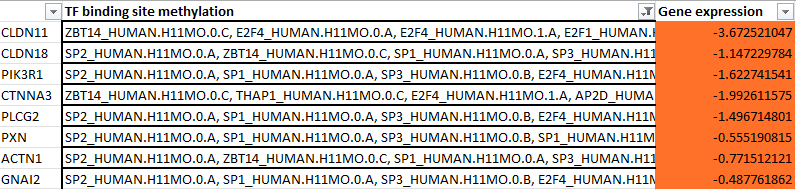

```r
knitr::include_graphics("methylation_diffGene.png")
```

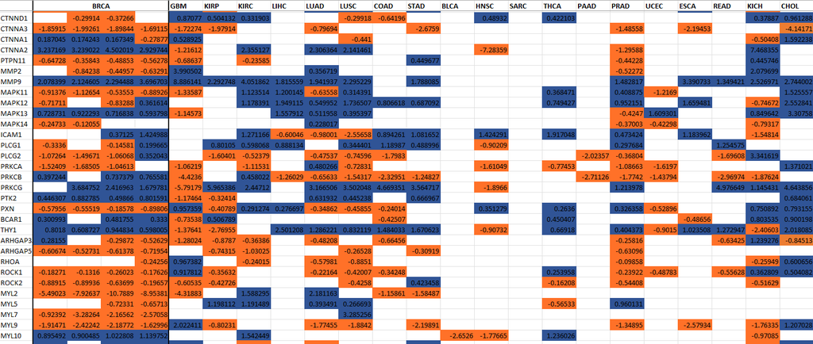

```r
knitr::include_graphics("pancancer_lfc.png")
```

## Conclusion

There is a lot that can be done using this workflow and the datasets produced by it. I am currently working on set of pathways associated with immune infiltration acorss pan-cancer. I will keep adding more R scripts here to take this workflow further to identify cross-network analysis combining methylation, gene expression. miRNA expression, copy number variants, and alternate splicing. I will keep you all posted.